# Gestió base de dades de mesures MRI dels pacients projecte ADNI.

```r
library(here)
library(kableExtra)
source(here("Rscripts","paths.R"))
load(here(cleandataDir,"demoData.RData"))
```

## 1. Lectura de base de dades amb informació de volums cerebrals.

La base de dades **volumes** recull informació de volums cerebrals per 13 subregions de l’hipocamp, tant per l’hemisferi esquerre com dret, així com el volum intracraneal estimat (27 variables), per a un total de 1405 pacients ADNI. Cada pacient s’identifica amb un codi numèric de quatre xifres, que figura tant a la variable *Subject* com *Suject2*. Cada pacient té diverses mesures preses, a diferent temps, recollit també al string de la variable *Subject*. Finalment, la resolució en tesla de les mesures està recollida a la variable *tesla*.

S’hi han realitzat les següents tasques:

- Extracació de l’identificador del pacient inclòs a la variable *Subject* en una nova variable *PTID*, amb un format coherent amb la resta de dades d’altres fonts.
- Extracció de la data en què es realitzà la mesura MRI corresponent a cada registre de la base de dades, a la variable *measureDate*.
- Unió amb la base de dades **patientInfo** de les variables *enrolDate* (data de la primera visita registrada a la base de dades demo) i *AGE* (edad basal a la data d’admissió al projecte).
- Calcular el lapse de temps en mesos *timelapse* entre cada mesura MRI registrada *measureDate* i la data d’entrada al projecte *enrolDate*, entesa com la data de la visita basal registrada a la base de dades de característiques demogràfiques. Comprovar que les mesures MRI basals haurien de tenir un valor proper a 0, mentre que les de seguiment haurien d’estar espaiades a 3,6,12,18,etc mesos.
- Detectar pacients pels que tots els registres de la base de dades presenten valors perduts, guardar el seu identificador PTID a l’objecte **PTwithnoData** i eliminar-ne els registres.
- Ordenar les observacions per nombre PTID i data de mesura MRI, reordenar les variables en un ordre lògic, i eliminar les variables innecessàries *Subject* i *Subject2*.

Com a resultat, es disposa d’un dataframe 6954 registres i 33 variables, corresponents a mesures per 1395 pacients diferents. Aquest n’és l’aspecte, mostrant les variables identificadores de la mesura i el pacient, i una de les 26 mesures de volum cerebral. Notar que encara hi ha 37 registres que presenten valors perduts a totes les mesures de volum. Es tractaran posteriorment.

```r
# =============================================================================
# A) IMPORT MRI VOLUMNE DATA and DATA WRANGLING
# =============================================================================

# It's been noticed at first glimpse that missing values appear encoded both as
# NA and "". What is more, it seems that several cases are corrupted,
# with strange values in some fields and even less fields than other registers.

volumes <- read.table(here(rawdataDir, "20211025_HSvolumes.txt"),
                   sep=" ", header=T, fill=T, na.strings = c("",NA))


# Save variable names for measurements -----------------------------
aux <- grep("(right|left|Total)",names(volumes))
volumeVars <- names(volumes)[aux]

# Extraiem el PTID de Subject2----------------------------------------
ptid <- volumes$Subject2
regex_PTID <- "^(\\d{3})_(\\w)_(\\d{4})$" # expected format

  #is there any PTID with a different format?
  #any(!grepl(regex_PTID,ptid))
    # we are good;all PTID are consistent format-wise.

# Replace PTID current value by only its last 4-digit code -----------------
volumes$PTID <- as.factor(gsub(regex_PTID,"\\3",volumes$Subject2))


# Extract Measure Date ---------------------------------------
regex_date <- "^(.*)_(\\d{4}-\\d{2}-\\d{2}).*$"
volumes$measureDate <- gsub(regex_date,"\\2",volumes$Subject)
volumes$measureDate <- as.Date(volumes$measureDate)

# From patientInfo dataset, join enrolment date and baseline age at that
# moment: enrolDate , AGE ----------------------------------------------
volumes <- merge(volumes,patientInfo[,c("PTID","enrolDate","AGE")], by="PTID")

# Calculate timelapse variable ------------------------------------
  # For each pacient, add their enrolment Date and calculate the time difference
  # between the measure date and the enrolment date.
volumes$timelapse <- with(volumes, measureDate-enrolDate)
  # Timelapse in months...
volumes$timelapse <- as.numeric(volumes$timelapse)/30

# Delete objects from Glob.Env with no further utility
rm(list=c("ptid","regex_PTID","regex_date"))

# =============================================================================
# B) MISSING VALUES
# =============================================================================

# Remove all patients with any measure at all. aka: all registers are NA
# values for all visits

  # i) Select those variables that have any missing value
varNA <- names(volumes)[sapply(volumes,function(x)any(is.na(x)))]

  # ii) Split databse by PTID and check if the sum of missing values
  #     is equal to the dataframe dimension, which would mean that
  #     all values are NA
volumes_byPT <- split(volumes,volumes$PTID)
aux <- sapply(volumes_byPT, FUN=function(x){
  sum(is.na(x[,varNA])) == Reduce('*',dim(x[,varNA]))})

  # iii) Select PTID whose registers are all NA
PTwithnoData <- names(aux)[aux]

# 10 pacients amb 37 mesures en total
#b <- volumes_byPT[aux]
#summary(do.call(rbind,b))
# Quedaran: 1395 pacients i 6954 registres

volumes <- subset(volumes, !(PTID %in% PTwithnoData))
volumes$PTID <- droplevels(volumes$PTID)
#length(unique(volumes$PTID)) #ok!


# Reorder variables in a more sensible order, and get rid of those that
# now are redundant. ----------------------------------------------------
volumes[c("Subject","Subject2")] <- NULL
volumes <- volumes[,c("PTID","AGE","measureDate","enrolDate","timelapse",
                      "tesla",volumeVars)]
#volumes[1:20,1:5]

# Arrange observations in a ascending order of PTID and measure date --------
volumes <- volumes[order(volumes$PTID,volumes$measureDate),]
rownames(volumes) <- NULL

# Remove objects from the global environment that are of no use anymore
rm(list=c("varNA","volumes_byPT","aux"))

volumes[1:10,1:7]
```

```
##    PTID  AGE measureDate  enrolDate  timelapse tesla left_Hippocampal_tail
## 1  0003 81.3  2005-09-01 2005-09-12 -0.3666667   1.5              484.7174
## 2  0003 81.3  2006-03-13 2005-09-12  6.0666667   1.5              479.5971
## 3  0003 81.3  2006-09-12 2005-09-12 12.1666667   1.5              454.0048
## 4  0003 81.3  2007-09-12 2005-09-12 24.3333333   1.5              438.3593
## 5  0004 67.5  2005-09-22 2005-11-08 -1.5666667   1.5              477.4947
## 6  0004 67.5  2006-05-25 2005-11-08  6.6000000   1.5              473.2856
## 7  0004 67.5  2006-11-28 2005-11-08 12.8333333   1.5              459.6289
## 8  0004 67.5  2007-05-25 2005-11-08 18.7666667   1.5              450.4643
## 9  0004 67.5  2008-12-09 2005-11-08 37.5666667   1.5              500.1194
## 10 0005 73.7  2005-09-02 2005-09-07 -0.1666667   1.5              439.3302
```

```r
str(volumes)
```

```
## 'data.frame':    6954 obs. of  33 variables:
##  $ PTID                         : Factor w/ 1395 levels "0003","0004",..: 1 1 1 1 2 2 2 2 2 3 ...
##  $ AGE                          : num  81.3 81.3 81.3 81.3 67.5 67.5 67.5 67.5 67.5 73.7 ...
##  $ measureDate                  : Date, format: "2005-09-01" "2006-03-13" ...
##  $ enrolDate                    : Date, format: "2005-09-12" "2005-09-12" ...
##  $ timelapse                    : num  -0.367 6.067 12.167 24.333 -1.567 ...
##  $ tesla                        : num  1.5 1.5 1.5 1.5 1.5 1.5 1.5 1.5 1.5 1.5 ...
##  $ left_Hippocampal_tail        : num  485 480 454 438 477 ...
##  $ left_subiculum               : num  269 266 280 300 346 ...
##  $ left_CA1                     : num  509 492 486 461 536 ...
##  $ left_hippocampal.fissure     : num  180 167 157 154 155 ...
##  $ left_presubiculum            : num  206 212 207 207 250 ...
##  $ left_parasubiculum           : num  41.1 42.4 41.5 35.7 40.9 ...
##  $ left_molecular_layer_HP      : num  431 428 423 412 519 ...
##  $ left_GC.ML.DG                : num  258 256 252 241 278 ...
```

[output cut: 19 more lines]

## 2. Distribució de les mesures segons tipus de resolució tesla

L’objectiu és doble: per una banda, veure com són les mesures dels pacients quant a la resolució en tesa, i si el pas de 1.5 a 3 tesla respon a l’evolució del projecte ADNI en el temps. I per altra, quina és la distribució del nombre de mesures MRI per pacient, segons la resolució emprada.

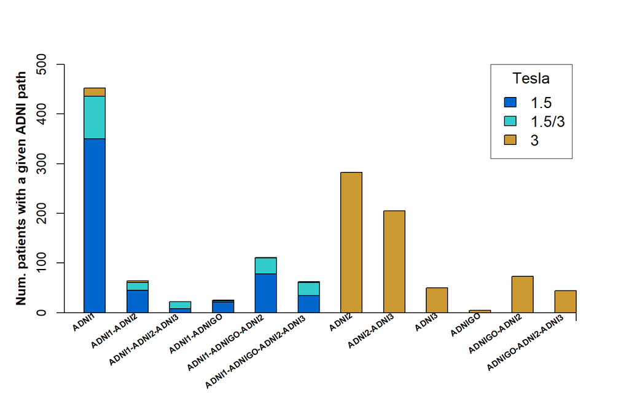

```r
# =============================================================================
# C) MEASUREMENT DISTRIBUTION BY TESLA TYPE
# =============================================================================

# FOR EACH PACIENT, GET THEIR PTID, NUMBER OF MRI MEASURES AND
# WHETHER THESE ARE ONLY IN 1.5 TESLA, 3 TESLA OR A MIX.
ptid_tesla <- lapply(split(volumes,volumes$PTID),function(x){
                nmeasures <- nrow(x)
                type <- paste(unique(x$tesla), collapse = "/")
                res <- data.frame(PTID=unique(x$PTID),
                                  tesla=type,
                                  numMRI_measures=nmeasures)
                return(res)
              })
ptid_tesla <- do.call(rbind,ptid_tesla)
ptid_tesla$tesla <- as.factor(ptid_tesla$tesla)
levels(ptid_tesla$tesla)[levels(ptid_tesla$tesla) == "3/1.5"] <- "1.5/3"

ptid_tesla <- merge(ptid_tesla,
                    patientInfo[,c("PTID","Path","numVisits")],
                    by="PTID")

#-----------------------------------------------------------------------------
# PLOT: number of patients with a given ADNI project path,
#       explained by type of measurement: 1.5T, 3T or 1.5/3 T
#-----------------------------------------------------------------------------
aux <- with(ptid_tesla, table(Path , tesla))
end_point <- 0.5 + nrow(aux) + nrow(aux) - 1

#png(file = here("figures","teslaMeasuresByAdniPhase.png"),
#    850,450)

barplot(t(aux),xaxt="n",space=1,ylim=c(0,500),
        col=c("#0066CC","#33CCCC","#CC9933"))
text(seq(1.5, end_point, by = 2), par("usr")[3]-0.25,
     srt = 35, adj = 1.05, xpd = TRUE,
     labels = paste(rownames(aux)), cex = 0.65,font=2)
legend(20,500,legend=colnames(aux),
       fill=c("#0066CC","#33CCCC","#CC9933"),
       title="Tesla",cex=1.2,box.lwd = 0)
mtext(side=2,text="Num. patients with a given ADNI path",
      line=2.3,cex=1,font=2)
axis(1,c(0,24),labels = F)
```

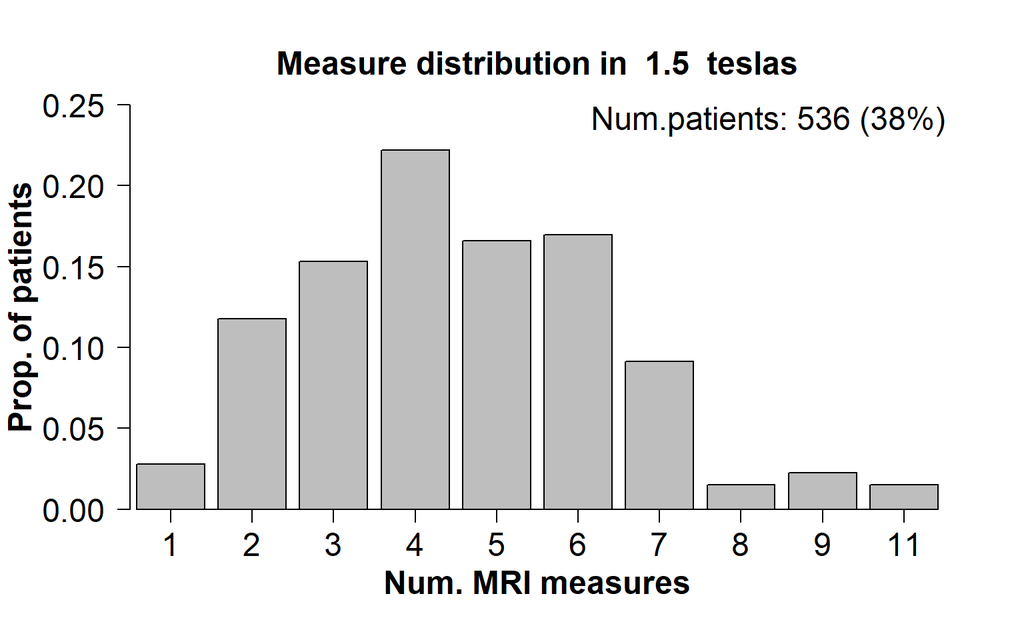

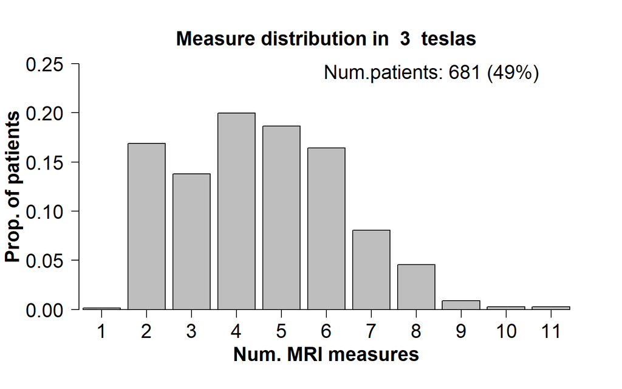

```r
#dev.off()

#------------------------------------------------------------------------
# PLOT: Distribution of number of MRI measurements for each patient,
#       both in 1 tesla and 3 teslas.
#-----------------------------------------------------------------------

# Proportion of measures for each tesla scenario
prop_teslaMeasures <- round(prop.table(table(ptid_tesla$tesla)),2)*100

# Select only 1 type of tesla measurement, and tabulate number of pacients
# with a certain number of MRI measurements
aux <- subset(ptid_tesla,tesla %in% c("1.5","3"))
aux$tesla <- droplevels(aux$tesla)
aux<- split(aux,aux$tesla)
numMeasures_byTesla <- lapply(aux, FUN= function(x){
                          res <- table(x$numMRI_measures)
                          attributes(res)$tesla <- unique(x$tesla)
                          return(res)
                        })

# BARPLOT
lapply(numMeasures_byTesla,function(x){
  # Auxiliary values
  numPT <- sum(x)
  aux <- which(names(prop_teslaMeasures) == attributes(x)$tesla)
  propPT <- prop_teslaMeasures[[aux]]

  # Make plot
  #file <- here("figures",paste0("measureDist_byTesla",
  #                             attributes(x)$tesla,".png"))
  #png(file,width = 800,height = 480)

  barplot(prop.table(x), las= 1, xlab=" ", ylab="", col="grey",
          cex.lab=1.7, cex.main=1.5, axes= F, ylim=c(0,.25),
          names.arg="")

  axis(1,seq(0.7,by=1.2,length.out=length(x)),labels = names(x),cex.axis=1.5)
  axis(2,seq(0,0.25,by=0.05),cex.axis=1.5,las=1,line=-1)
  mtext("Num. MRI measures",side=1, line=2.5, cex=1.5, font=2)
  mtext("Prop. of patients",side=2, line=2.7, cex=1.5, font=2)
  mtext(paste("Measure distribution in ",
              attributes(x)$tesla," teslas"),
        side=3, line=1, cex=1.5, font=2)
  text(x=9.5,y=0.24,labels = paste0("Num.patients: ",sum(x),
                                    " (",propPT,"%)"),
       cex=1.5)

  #dev.off()
})
```

```r
# Delete objects from GE with no further utility
rm(list=c("aux","numMeasures_byTesla","end_point","prop_teslaMeasures"))
```

Notar que hi ha alguns pacients amb només una mesura, i que per tant no tenen un seguiment longitudinal com a tal. Per altra banda, s’observa que a partir del projecte ADNIGO o ADNI2, les mesures són totes a 3 tesla, i que les mesures a 1.5 corresponent exclusivament a pacients que iniciaren la seva participació a l’inici del projecte amb ADNI1. A part, existeixen alguns pacients pilot pels que es disposa o bé de dues sèries de mesures paral·leles a dues resolucions, o bé existeix un salt en la resolució en el moment en que s’inicien fases noves del projecte.

Per aquest motiu, es tractaran per separat els pacients amb mesures d’una única resolució (1.5 o 3 T) i els pacients amb mescla de resolucions.

## 3. Gestió de les dades pacients amb mesures d’una única resolució tesla.

```r
# PTID with repeated measures, both in 1.5 and ---------------------------
# 3 teslas for similar dates----------------------------------------------
aux <- lapply(split(volumes,volumes$tesla),function(x)unique(x$PTID))
PTID_withBothTeslaMeasure <- Reduce(intersect,aux)
#length(PTID_withBothTeslaMeasure)
  # dels 1395 PTID amb mesures, 178 tenen mesures en dos teslas,
  # mentre que 1217 pacients només tenen mesures d'un tipus.
```

Quant als pacients amb un sol tipus de resolució tesla, es realitzen les següents tasques:

- **Fer el subset de les dades, en un nou dataset volumes_singleT.**

```r
#----------------------------------------------------------------------------
# D.1) SINGLE TESLA MEASUREMENTS
#       i) Subset
#       ii) Deal with incomplete and NA registers
#       iii) Classify measures as baseline and follow-up
#       iv) Set a longitudinal time measurement, based on enrollment date
#           for each patient.
#----------------------------------------------------------------------------

################
# i) SUBSET
################
volumes_singleT <- volumes[!(volumes$PTID %in% PTID_withBothTeslaMeasure),]
  # 5550 registres de 1217 pacients diferents
```

- **Explorar i tractar els pacients amb valors perduts.**

```r
############################
# ii) Corrupted registers
############################
  # Patients with missing values. Save them apart at 'rareCases' dataframe
aux <- unique(volumes_singleT[!complete.cases(volumes_singleT),"PTID"])
rareCases <- volumes_singleT[volumes_singleT$PTID %in% aux,]
  # 5 patients with corrupted registers or only 1 or 2 sparse measurements,
  # with NA for the rest.

  # Remove them from dataset: 1212 patients, 5522 registers
volumes_singleT <- subset(volumes_singleT,subset=!(PTID %in% aux))
volumes_singleT$PTID <- droplevels(volumes_singleT$PTID)

rareCases[,1:7]
```

```
##      PTID  AGE measureDate  enrolDate  timelapse tesla left_Hippocampal_tail
## 433  0127 70.6  2006-02-14 2006-02-24 -0.3333333   1.5                    NA
## 434  0127 70.6  2006-09-01 2006-02-24  6.3000000   1.5                    NA
## 435  0127 70.6  2007-03-27 2006-02-24 13.2000000   1.5              443.0427
## 436  0127 70.6  2008-03-13 2006-02-24 24.9333333   1.5                    NA
## 437  0127 70.6  2009-03-27 2006-02-24 37.5666667   1.5                    NA
## 438  0127 70.6  2010-04-19 2006-02-24 50.5000000   1.5                    NA
## 439  0127 70.6  2011-07-28 2006-02-24 66.0000000   1.5                    NA
## 440  0127 70.6  2012-02-27 2006-02-24 73.1333333   1.5                    NA
## 640  0204 71.1  2006-02-14 2006-02-23 -0.3000000   1.5                    NA
## 641  0204 71.1  2007-02-22 2006-02-23 12.1333333   1.5                    NA
## 642  0204 71.1  2007-08-30 2006-02-23 18.4333333   1.5                    NA
## 643  0204 71.1  2008-03-06 2006-02-23 24.7333333   1.5                    NA
## 644  0204 71.1  2009-03-05 2006-02-23 36.8666667   1.5                    NA
## 645  0204 71.1  2010-02-05 2006-02-23 48.1000000   1.5              319.9485
## 1668 0557 72.0  2006-05-31 2006-06-08 -0.2666667   1.5                    NA
## 1669 0557 72.0  2006-12-19 2006-06-08  6.4666667   1.5                    NA
## 1670 0557 72.0  2007-12-04 2006-06-08 18.1333333   1.5              499.4310
## 1671 0557 72.0  2009-06-06 2006-06-08 36.4666667   1.5              489.1580
## 2249 0782 81.6  2007-04-11 2006-08-23  7.7000000   1.5              510.5686
## 2250 0782 81.6  2007-09-19 2006-08-23 13.0666667   1.5                    NA
## 2251 0782 81.6  2008-06-18 2006-08-23 22.1666667   1.5                    NA
## 2252 0782 81.6  2008-10-17 2006-08-23 26.2000000   1.5                    NA
## 2253 0782 81.6  2009-09-04 2006-08-23 36.9333333   1.5                    NA
## 2858 1007 72.3  2006-10-25 2006-11-14 -0.6666667   1.5                    NA
## 2859 1007 72.3  2007-05-09 2006-11-14  5.8666667   1.5                    NA
## 2860 1007 72.3  2008-04-23 2006-11-14 17.5333333   1.5              320.6833
## 2861 1007 72.3  2008-11-05 2006-11-14 24.0666667   1.5                    NA
## 2862 1007 72.3  2009-11-04 2006-11-14 36.2000000   1.5                    NA
```

- **Classificació de les mesures en basal o de seguiment a 3,6,18… mesos, depenent del valor de *timelapse* calculat anteriorment.**

Prèviament, per cada pacient es comprova la distribució del *timelapse* per la primera mesura MRI realitzada. Com pot observar-se a l’histograma i a la distribució dels quantils, el 92% de les primeres mesures MRI per cada pacient es realitzaren abans que la primera visita (enrolDate) registrada a la base de dades demogràfica, que com s’ha dit es considera la data d’entrada al projecte i per la qual es registra l’edat del participant entre d’altres. Només el 3.5% dels pacients presenten una priemra mesura 2 o més mesos abans que la primera visita.

Així doncs, a l’hora d’assignar la primera mesura MRI com a basal, es consideraran aquelles preses com a molt 2 mesos abans de la data de priemra visita, i com a molt tard mes i mig després; les anteriors es descarten, i les posteriors ja es consideren mesura de seguiment als 3 mesos (no arriben al 2% de les primeres mesures). La resta de mesures (6% de primeres mesures) amb un *timelapse* superior a 0, corresponen a pacients en els que no disposen de mesura basal, sinó que la primera mesura es realitza al menys passats 3 mesos de la primera visita.

Per altra banda, a l’hora de classificar les mesures de seguiement, es consideren els mateixos nivells que consten a la base de dades **demo**, on les visites de seguiment es realitzen als 3 mesos, 6 mesos, i cada 6 mesos fins als 132 mesos, quan el seguiement passa a ser anual. El límit entre un grup i un altre es fixa a la meitat de l’interval.

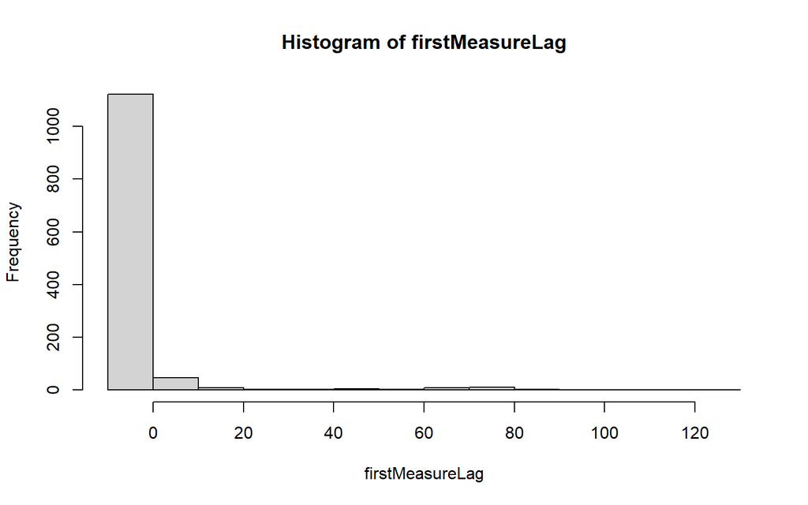

```r
###############################
# iii) CLASSIFY MEASURE AS BASELINE OR 3,6,12...FOLLOW-UP MEASURE DEPENDING
#      ON THE TIME DIFFERENCE BETWEEN MEASURE DATE AND ENROL DATE FOR EACH
#      PACIENT (first visit date for each pacient in demo dataset)
##############################

  # a) Check what the delay might be between the first MRI measure and
  #     the day when the patient enrolled the project (date of the first visit)
  firstMeasureLag <- sapply(split(volumes_singleT,volumes_singleT$PTID),
                            FUN='[',1,"timelapse",drop=T)
  hist(firstMeasureLag)
```

```r
  quantile(firstMeasureLag,seq(0,1,by=0.01))[93:101]
```

```
##         92%         93%         94%         95%         96%         97%
##   0.0000000   0.2486667   2.1780000   5.8333333   6.3226667  18.9933333
##         98%         99%        100%
##  50.9013333  69.9570000 125.6666667
```

```r
  quantile(firstMeasureLag,seq(0,1,by=0.005))[1:10]
```

```
##      0.0%      0.5%      1.0%      1.5%      2.0%      2.5%      3.0%      3.5%
## -5.866667 -3.476167 -2.792667 -2.494500 -2.359333 -2.233333 -2.089000 -2.000000
##      4.0%      4.5%
## -1.885333 -1.833333
```

```r
    # The majority of patients had their first MRI measure taken before
    # their baseline first visit took place.
    # 3.5% of patients have a first measure 2 or more months before
    # first visit.
    # Among those patients that had their first MRI measurement taken
    # AFTER first visit, 15% of them were measured within the next 1.5 month,
    # for which is still reasonable to consider them as baseline measure.
    # A bigger timelapse means that the first measure is no a baseline, but
    # a follow-up one (3-6-12-18... months after enrolment).

  # b) With all that said, measures with a time-lapse lower than -2 months
  #     will not be considered, and should be removed. (42 obs.)
  volumes_singleT <- subset(volumes_singleT, !timelapse<(-2))

  # e) Assign each measurement a VISCODE code: bl, m03, m06, m12, m18...
  #    according to timelapse value.
  breaks <- c(-Inf,1.5,4.5,seq(10.5,130.5,by=6),138,150,162)
  labels <- levels(demo$VISCODE2)
  aux <- lapply(split(volumes_singleT,volumes_singleT$PTID),
                function(x){x$VISCODE2 <-
                              cut(x$timelapse,
                                  breaks=breaks,
                                  labels=labels,
                                  include.lowest=T)
                            return(x)
                           })
  aux <- do.call(rbind,aux)
```

- **Creació de la variable *time*, com a mesura de temps longitudinal per cada pacient.**

Com a mesura longitudinal de temps, es considera l’edat del pacient al moment de mesura, prenent com a referència l’edat registrada a la primera visita o moment d’entrada al projecte. Per calcular-la, al lapse de temps *timelapse* entre mesura MRI i data de primera visita, se li suma l’edat basal a la primera visita.

```r
##############################
# iv) Longitudinal time measurement: current patient age, calculated
#    as age at enrolment plus time-lapse between enrolment date and
#    measurement date.
################################
  aux$time <- with(aux, AGE + (timelapse/12),3)

  # RESULT DATAFRAME
  volumes_singleT <- aux[,c("PTID","tesla","VISCODE2",
                            "enrolDate","AGE","measureDate",
                            "timelapse","time",
                            volumeVars)]


  rownames(volumes_singleT) <- NULL
  volumes_singleT[1:9,c(1,3:9)]
```

```
##   PTID VISCODE2  enrolDate  AGE measureDate  timelapse     time
## 1 0003       bl 2005-09-12 81.3  2005-09-01 -0.3666667 81.26944
## 2 0003      m06 2005-09-12 81.3  2006-03-13  6.0666667 81.80556
## 3 0003      m12 2005-09-12 81.3  2006-09-12 12.1666667 82.31389
## 4 0003      m24 2005-09-12 81.3  2007-09-12 24.3333333 83.32778
## 5 0004       bl 2005-11-08 67.5  2005-09-22 -1.5666667 67.36944
## 6 0004      m06 2005-11-08 67.5  2006-05-25  6.6000000 68.05000
## 7 0004      m12 2005-11-08 67.5  2006-11-28 12.8333333 68.56944
## 8 0004      m18 2005-11-08 67.5  2007-05-25 18.7666667 69.06389
## 9 0004      m36 2005-11-08 67.5  2008-12-09 37.5666667 70.63056
##   left_Hippocampal_tail
## 1              484.7174
## 2              479.5971
## 3              454.0048
## 4              438.3593
## 5              477.4947
## 6              473.2856
## 7              459.6289
## 8              450.4643
## 9              500.1194
```

```r
  rm(list=c("firstMeasureLag","breaks","labels"))
```

### Correspondència de mesures MRI amb visites

Per mirar si les mesures MRI i les visites de la base de dades **demo** coincideixen, fem un merge per PTID i VISCODE2.

```r
vol <- volumes_singleT[,c("PTID","VISCODE2","enrolDate",
                          "measureDate","timelapse")]
m <- merge(vol,demo[,c("PTID","VISCODE2","EXAMDATE")],
           by=c("PTID","VISCODE2"),all.x=T)
m$dif <- as.numeric(m$EXAMDATE-m$measureDate)/30
m <- split(m,m$PTID)

m$`0005`
```

```
##    PTID VISCODE2  enrolDate measureDate  timelapse   EXAMDATE       dif
## 10 0005       bl 2005-09-07  2005-09-02 -0.1666667 2005-09-07 0.1666667
## 11 0005      m06 2005-09-07  2006-03-09  6.1000000 2006-03-09 0.0000000
## 12 0005      m12 2005-09-07  2006-09-05 12.1000000 2006-09-05 0.0000000
## 13 0005      m24 2005-09-07  2007-09-07 24.3333333 2007-09-07 0.0000000
## 14 0005      m36 2005-09-07  2008-09-10 36.6333333 2008-09-10 0.0000000
```

Com es pot observar, en la majoria dels casos la diferència entre la measureDate i la EXAMDATE es poca. Però en cert casos, hi ha discrepàncies.

```r
problems <- sapply(m,function(x)any(abs(x$dif)>2.5,na.rm = T))
problems <- m[problems]
length(problems)
```

```
## [1] 49
```

En 49 pacients en què hi ha discrepàncies majors que dos mesos i mig. Per exemple, el cas 0042, la mesura de 2010-03-18 està presa 53 mesos després de la primera visita, de manera que es classifica al grup més proper, m54. Tanmateix, a la base de dades **demo**, la classificació VISCODE per a aquesta data és de m48. Mirant les diferències reals *dif* entre *EXAMDATE* i data primera visita, es veu que els m48, m54, m60 i m66 discrepen amb el temps real.

```r
# Exemple
v <- problems$`0042`
d <- subset(demo,PTID=="0042",select=c("PTID","VISCODE2","EXAMDATE"))
d$dif <- as.numeric(d$EXAMDATE - d$EXAMDATE[1])/30

v
```

```
##    PTID VISCODE2  enrolDate measureDate  timelapse   EXAMDATE         dif
## 73 0042       bl 2005-11-10  2005-10-31 -0.3333333 2005-11-10  0.33333333
## 74 0042      m06 2005-11-10  2006-05-03  5.8000000 2006-05-02 -0.03333333
## 75 0042      m12 2005-11-10  2006-11-09 12.1333333 2006-11-09  0.00000000
## 76 0042      m18 2005-11-10  2007-06-08 19.1666667 2007-05-10 -0.96666667
## 77 0042      m24 2005-11-10  2007-12-03 25.1000000 2007-11-30 -0.10000000
## 78 0042      m36 2005-11-10  2008-12-05 37.3666667 2008-12-05  0.00000000
## 79 0042      m54 2005-11-10  2010-03-18 52.9666667 2010-11-08  7.83333333
## 80 0042      m66 2005-11-10  2011-04-13 66.0000000 2011-10-17  6.23333333
## 81 0042      m72 2005-11-10  2011-11-30 73.7000000 2011-11-30  0.00000000
## 82 0042      m84 2005-11-10  2013-01-23 87.7000000 2013-01-23  0.00000000
## 83 0042      m96 2005-11-10  2013-11-21 97.7666667 2013-11-21  0.00000000
```

```r
d
```

```
##     PTID VISCODE2   EXAMDATE        dif
## 207 0042       bl 2005-11-10   0.000000
## 208 0042      m06 2006-05-02   5.766667
## 209 0042      m12 2006-11-09  12.133333
## 210 0042      m18 2007-05-10  18.200000
## 211 0042      m24 2007-11-30  25.000000
## 212 0042      m30 2008-06-24  31.900000
## 213 0042      m36 2008-12-05  37.366667
## 214 0042      m42 2009-05-11  42.600000
## 215 0042      m48 2010-03-18  52.966667
## 216 0042      m54 2010-11-08  60.800000
## 217 0042      m60 2011-04-13  66.000000
## 218 0042      m66 2011-10-17  72.233333
## 219 0042      m72 2011-11-30  73.700000
## 220 0042      m78 2012-06-20  80.466667
## 221 0042      m84 2013-01-23  87.700000
## 222 0042      m90 2013-05-17  91.500000
## 223 0042      m96 2013-11-21  97.766667
## 224 0042     m102 2014-05-12 103.500000
```

## 4. Gestió de les dades pacients amb mescla de resolució tesla en les mesures.

Els pacients amb resolucions mesclades s’agrupen en dues categories: una sola sèrie de mesures longitudinals, que s’inicien a 1.5 i a cert punt canvien a 3T; i d’altres que presenten dues seqüències paral·lelels de mesures, a 1.5 i 3T.

Quant als pacients amb dues sèries de mesures, sembla haver-hi força casuística:

```r
#----------------------------------------------------------------------------
# D.2) BOTH TESLA-TYPE MEASUREMENTS
#       i) Subset
#       ii) Deal with incomplete and NA registers
#       iii) Classify measures as baseline and follow-up
#       iv) Set a longitudinal time measurement, based on enrollment date
#           for each patient.
#----------------------------------------------------------------------------

################
# i) SUBSET
################
get_viscode <- function(x){
  breaks <- c(-2,1.5,4.5,seq(10.5,130.5,by=6),138,150,162)
  labels <- levels(demo$VISCODE2)

  res <- within(x,{

    VISCODE2 <- cut(timelapse, breaks=breaks,labels=labels,include.lowest=T)
  })
  return(res)
}



volumes_bothT <- volumes[volumes$PTID %in% PTID_withBothTeslaMeasure,]
volumes_bothT$PTID <- droplevels(volumes_bothT$PTID)
#1404 observations, 178 patients

aux <- with(volumes_bothT, order(PTID,tesla,measureDate))
volumes_bothT <- volumes_bothT[aux,]

volumes_bothT <- get_viscode(volumes_bothT)

prova <- volumes_bothT[,c("PTID","AGE","tesla","measureDate","enrolDate",
                      "timelapse","VISCODE2")]

a <- split(prova,prova$PTID)


dups <- sapply(a,function(x)any(table(x$VISCODE2)>1))

#Mesures amb dues seqüències
b <- a[dups]

# Mesures amb una seqüència
c <- a[!dups]
```

- **Dues series, amb baseline i nombre semblant de mesures**

```r
b$`0015`
```

```
##    PTID  AGE tesla measureDate  enrolDate  timelapse VISCODE2
## 34 0015 80.8   1.5  2005-09-26 2005-10-18 -0.7333333       bl
## 36 0015 80.8   1.5  2006-04-18 2005-10-18  6.0666667      m06
## 39 0015 80.8   1.5  2006-10-17 2005-10-18 12.1333333      m12
## 41 0015 80.8   1.5  2009-04-06 2005-10-18 42.2000000      m42
## 35 0015 80.8   3.0  2005-10-31 2005-10-18  0.4333333       bl
## 37 0015 80.8   3.0  2006-05-02 2005-10-18  6.5333333      m06
## 38 0015 80.8   3.0  2006-10-16 2005-10-18 12.1000000      m12
## 40 0015 80.8   3.0  2007-10-11 2005-10-18 24.1000000      m24
## 42 0015 80.8   3.0  2009-04-27 2005-10-18 42.9000000      m42
```

- **Dues series, una sense mesura baseline**

```r
b$`0035`
```

```
##     PTID  AGE tesla measureDate  enrolDate  timelapse VISCODE2
## 96  0035 76.9   1.5  2005-10-20 2005-11-08 -0.6333333       bl
## 98  0035 76.9   1.5  2006-06-06 2005-11-08  7.0000000      m06
## 99  0035 76.9   1.5  2006-11-30 2005-11-08 12.9000000      m12
## 97  0035 76.9   3.0  2006-05-15 2005-11-08  6.2666667      m06
## 100 0035 76.9   3.0  2007-11-06 2005-11-08 24.2666667      m24
## 101 0035 76.9   3.0  2009-03-19 2005-11-08 40.9000000      m42
```

- **Dues series amb baseline, la de 3 tesla amb menys mesures**

```r
#Dues series, 3 tesla amb menys mesures
b$`0058`
```

```
##     PTID  AGE tesla measureDate  enrolDate timelapse VISCODE2
## 184 0058 70.1   1.5  2005-11-30 2005-12-12  -0.40000       bl
## 187 0058 70.1   1.5  2006-06-22 2005-12-12   6.40000      m06
## 188 0058 70.1   1.5  2006-12-19 2005-12-12  12.40000      m12
## 189 0058 70.1   1.5  2007-12-06 2005-12-12  24.13333      m24
## 191 0058 70.1   1.5  2010-03-19 2005-12-12  51.93333      m48
## 192 0058 70.1   1.5  2011-04-27 2005-12-12  65.40000      m66
## 193 0058 70.1   1.5  2012-04-02 2005-12-12  76.76667      m78
## 194 0058 70.1   1.5  2013-12-04 2005-12-12  97.13333      m96
## 185 0058 70.1   3.0  2005-12-12 2005-12-12   0.00000       bl
## 186 0058 70.1   3.0  2006-06-13 2005-12-12   6.10000      m06
## 190 0058 70.1   3.0  2008-12-09 2005-12-12  36.43333      m36
```

Per escollir quina de les dues seqüències es conserva, per cada pacient es proposa el següent arbre de decisió:

- Tenen totes dues mesura basal? Si no, retenim la sèrie amb mesura basal; si és així…
- Tenen un nombre de mesures semblant? Si no, es reté la sèrie amb més mesures. Si el nombre és semblant…
- Es reté la sèrie de major resolució, a 3 tesla.

A tal fi, s’elabora la següent taula per filtrar, on es recull el nombre d’observacions a cada resolució i si cada una de les sèries tenen o no mesura basal.

```r
f <- function(x){
  counts <- table(x$tesla)
  bl_1T <- any(x[x$tesla=="1.5","VISCODE2"] == "bl")
  bl_3T <- any(x[x$tesla=="3","VISCODE2"] == "bl")

  res <- data.frame(numMes_1.5=counts[1],
                    numMes_3 = counts[2],
                    bl_1T = bl_1T,
                    bl_3T = bl_3T)
  return(res)
}

res <- t(sapply(b,f))
res <- data.frame(PTID=rownames(res),res)
rownames(res) <- NULL


head(res)
```

```
##   PTID numMes_1.5 numMes_3 bl_1T bl_3T
## 1 0015          4        5  TRUE  TRUE
## 2 0031          5        5  TRUE  TRUE
## 3 0035          3        3  TRUE FALSE
## 4 0058          8        3  TRUE  TRUE
## 5 0061          6        4 FALSE  TRUE
## 6 0078          4        4  TRUE  TRUE
```

## 5. Consultes

- Creieu adequada la manera de decidir si la primera mesura d’un pacient és o no la basal, en funció del lapse de temps entre la mesura i la primera visita?
- Us sembla correcte com s’ha construït la mesura **time** pel seguiment longitudinal dels pacients, com la suma de l’edat reportada a la primera visita més el lapse de temps entre la mesura MRI i la data de la priemra visita?
- Malgrat que en alguns casos costa fer el merge de les dates de mesura i MRI i les visites segons el codi VISCODE, ja sigi perquè es donen en dies diferents o el VISCODE de la base de dades *demo* no correspon amb la diferècia real de temps, crec que no té gaire efecte a l’hora de treballar i és complicat fer-ho casar tot. El que realment importa és el lapse de temps entre la data de mesura i la data de primera visita. Esteu d’acord?
- Pels pacients amb dues seqüències, he fet la taula que la Patricia va proposar, i hi he afegit el tema de si tenen o no mesura baseline. Us sembla correcte la manera de decidir quina seqüència conservar?
- Finalment, què seria millor fer, dues bases de dades amb mesures a 1.5T i 3T? O mesclar-les i incloure tesla com a variable?